# Ford gobike visualization project

## by Hussam Mohamed Ali Elzaphry

> The Ford gobike dataset is a one month of collective data from bike users in San Fransisco

### Dataset structure

> More than 183000 records with 15 fields of data

### Main features of interest in dataset

> - Analyse the trip records per day-hour, and week-day.
> - Analyse duration per gender, user type, member birth year, and more.
> - Analyse stations with frequent service usage.
> - Analyse univariant plots for categorical data like user type

### Features in the dataset that support investigation into dataset features of interest

> The timing and duration field are probably the most important. Also the user data like gender and birth year will have some direct impact on our study

### Gender and Service Subscription Analysis

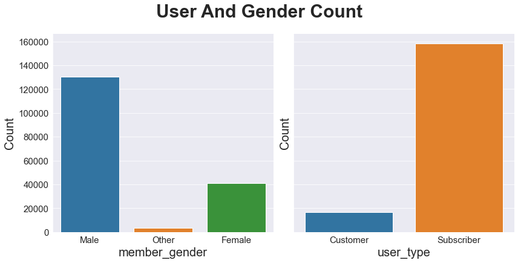

- Most of the service users are subscribed users.
- Also males make more trips than females.

  > May be females would be targeted in marketing campaigns, especially when noticing the following average trip durations study.

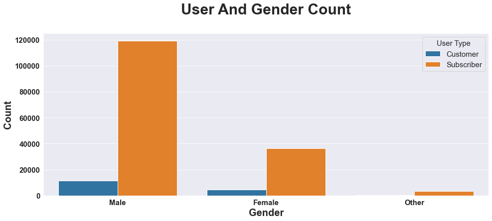

Side by side comparison between users type and gender

### Gender and Service Subscription Trip Duration

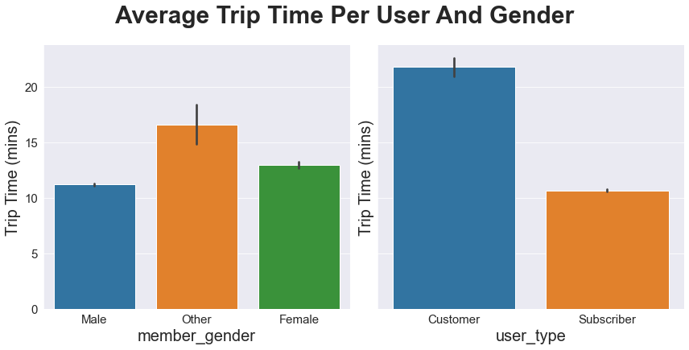

- Females tend to spend more time on their trips
- Also unsubscriped customers tend to spend on average more time on their trips.
- (gender "Other") and missing data like birth year also record more trip time durations

  > This may refer to inconvenient in regestration process, knowing that gender "Others" and type "Customer" tend spend significant time on their trips.

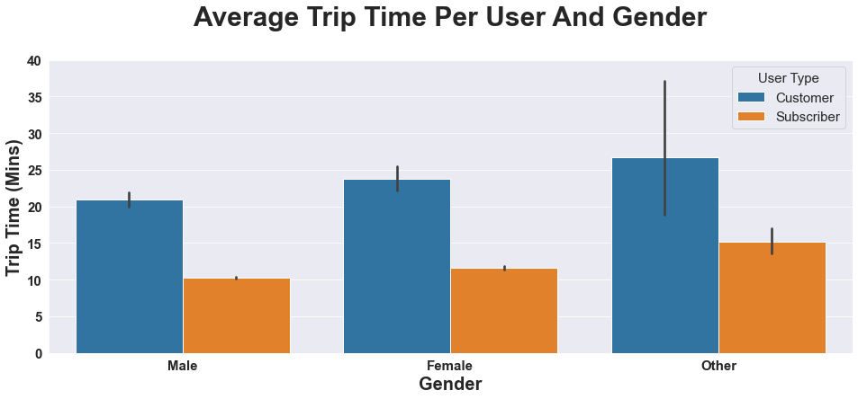

Side by side comparison between users type and gender in regards to trip time

### Duration time distribution

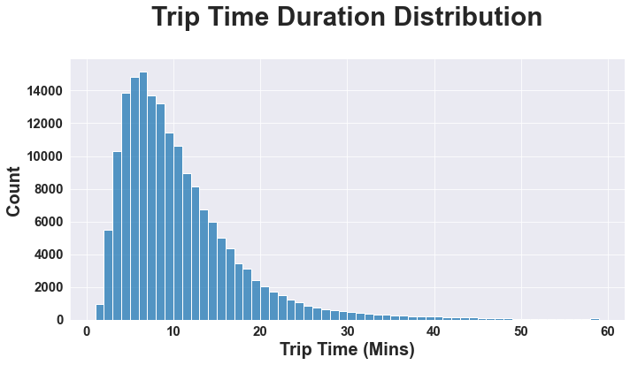

This shows that the average timp times are between a minute and half an hour

### Users Birth Year Analysis

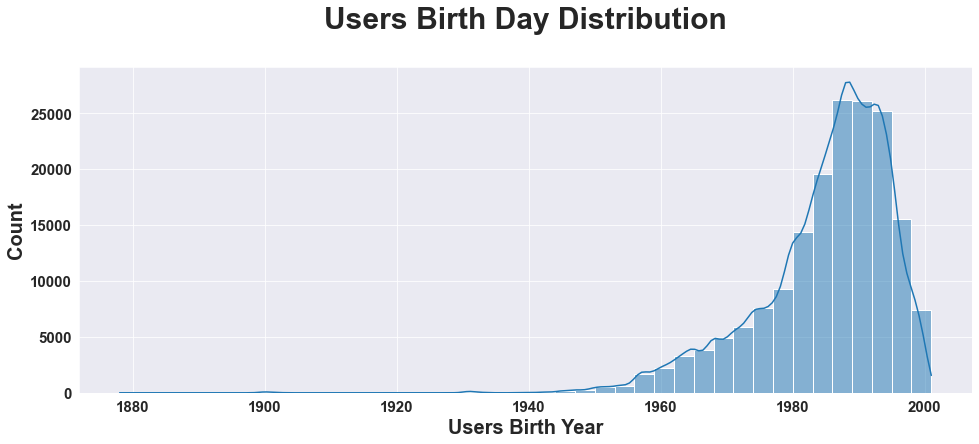

Most of the service users are born between 80, and 92

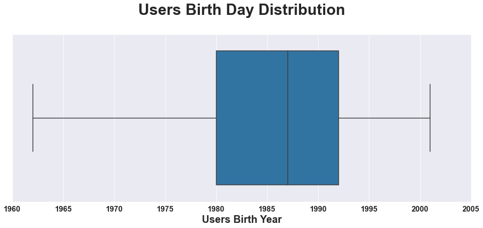

This boxplot shows the distribution of service users birth year

### Time Trip Analysis per Users birth year

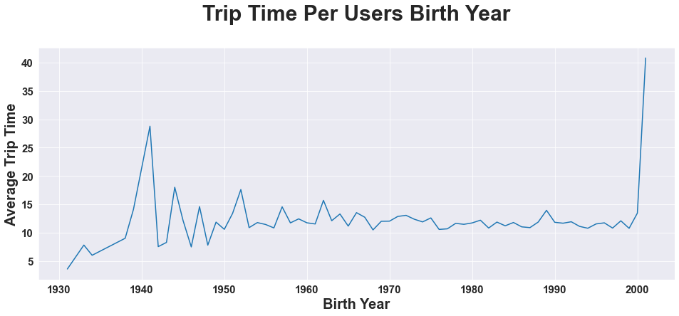

However, people from other birth years spend signifcant time in their trips, back to the year of 1940.

### Daily frequent hours of service usage

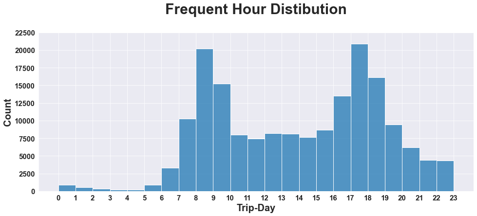

Most trips are at the time of 8 am, and 5 pm.

### Weekly frequent Days of service usage

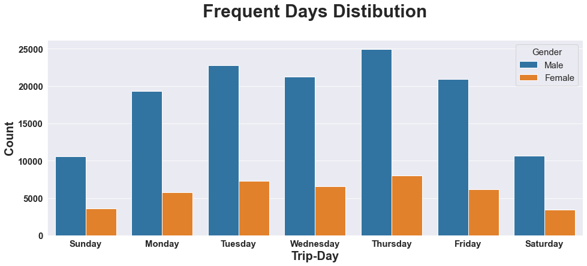

Most of trips are on Thursday

### Weekly Frequent times and days on a Heatmap

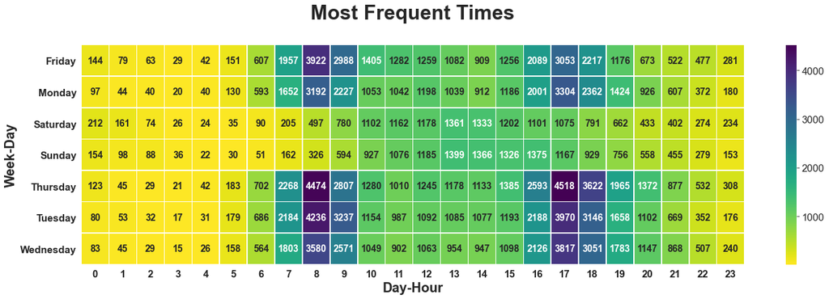

This shows the dense times along the week in hours and days

### Most popular starting stations

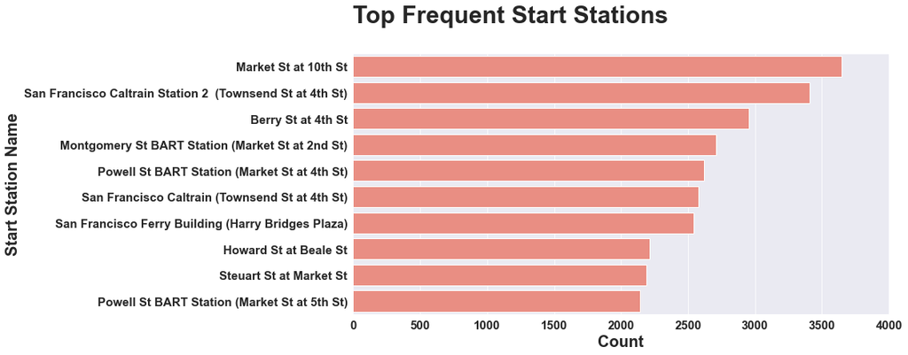

Most popular starting stations are: San Francisco Caltrain Station 2, and Market St at 10th St,

### Most popular ending stations are

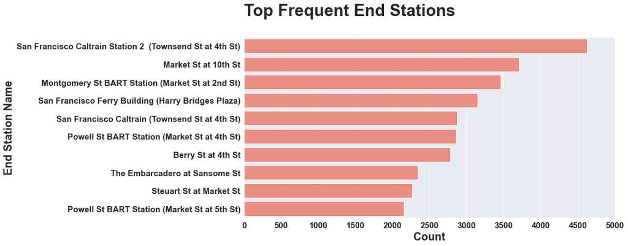

Most popular ending stations are: San Francisco Caltrain Station 2, and Market St at 10th St,

> which we can use to enhance the service targeting dense stations at crowd times with more bikes.